# Modeling_Hotel Cancellation Prediction

## Predicting Hotel Booking Cancellations using a Voting Classifier

### Notebook 2: modeling, and model evaluation

#### Amro Shanshal

This booking website has a dataset of hotel cancellations and would like a data scientist to build a classification model that predicts future cancellations. They have provided me with a number of metrics/features that are relevant to the problem. The 32 features they provided are within the following buckets:

- Hotel type, room and stay
- previous stays
- location
- booking logistics
- Payment
- customer

I built a solution that includes data cleaning, Explartory Data Analysis (EDA), feature engineering, model building and evaluation

Importing necessary libraries

```python
%matplotlib inline
import pandas as pd
import numpy as np
import matplotlib.pyplot as plt
from matplotlib import pyplot
import seaborn as sns

import warnings
warnings.filterwarnings("ignore")

from sklearn.preprocessing import LabelEncoder
from sklearn.preprocessing import StandardScaler
from sklearn.model_selection import train_test_split

from sklearn.model_selection import StratifiedKFold
from sklearn.model_selection import GridSearchCV


from sklearn.inspection import permutation_importance

from sklearn.ensemble import RandomForestClassifier
from sklearn.ensemble import ExtraTreesClassifier
from sklearn.tree import DecisionTreeClassifier
from sklearn.ensemble import GradientBoostingClassifier
from sklearn.ensemble import VotingClassifier

from sklearn.metrics import accuracy_score
from sklearn.model_selection import cross_val_score
from sklearn.metrics import classification_report
from sklearn.metrics import confusion_matrix

from nose.tools import assert_equal, assert_is_instance, assert_is_not
from numpy.testing import assert_array_equal, assert_array_almost_equal, assert_almost_equal
from pandas.util.testing import assert_frame_equal

import plotly.express as px
import plotly.graph_objects as go
import plotly.figure_factory as ff
from plotly.colors import n_colors
from plotly.subplots import make_subplots
# Minmax scaler
from sklearn.preprocessing import MinMaxScaler
import datetime

from sklearn.tree import DecisionTreeClassifier
from sklearn.model_selection import GridSearchCV

# Import accuracy_score
from sklearn.metrics import accuracy_score
from sklearn.ensemble import RandomForestClassifier
#Import DecisionTreeClassifier from sklearn.tree
from sklearn.tree import DecisionTreeClassifier
from sklearn.model_selection import cross_validate
from sklearn.model_selection import cross_val_score
from sklearn.tree import export_text

from sklearn.neighbors import KNeighborsClassifier
from sklearn import datasets
from matplotlib import pyplot as plt
from sklearn.ensemble import GradientBoostingClassifier
from sklearn.model_selection import RandomizedSearchCV
from xgboost import XGBClassifier
import shap
from catboost import CatBoostClassifier
from sklearn.ensemble import VotingClassifier
from sklearn import metrics

from sklearn.ensemble import RandomForestClassifier
from sklearn.linear_model import LogisticRegression
```

```python
# import training data
df = pd.read_csv("Cleaned df.csv",index_col=None)
df.head()
```

|  | is_canceled | lead_time | adults | meal | country | market_segment | is_repeated_guest | previous_cancellations | previous_bookings_not_canceled | reserved_room_type | ... | days_in_waiting_list | customer_type | adr | required_car_parking_spaces | total_of_special_requests | stays_total | kids | same_room_type | is_cityhotel | arrival_day_of_week |
| --- | --- | --- | --- | --- | --- | --- | --- | --- | --- | --- | --- | --- | --- | --- | --- | --- | --- | --- | --- | --- | --- |
| 0 | 0 | 7 | 1 | 0 | 59 | 3 | 0 | 0 | 0 | 0 | ... | 0 | 2 | 75.0 | 0 | 0 | 1 | 0.0 | 0 | 0 | 2 |
| 1 | 0 | 13 | 1 | 0 | 59 | 2 | 0 | 0 | 0 | 0 | ... | 0 | 2 | 75.0 | 0 | 0 | 1 | 0.0 | 1 | 0 | 2 |
| 2 | 0 | 14 | 2 | 0 | 59 | 6 | 0 | 0 | 0 | 0 | ... | 0 | 2 | 98.0 | 0 | 1 | 2 | 0.0 | 1 | 0 | 2 |
| 3 | 0 | 14 | 2 | 0 | 59 | 6 | 0 | 0 | 0 | 0 | ... | 0 | 2 | 98.0 | 0 | 1 | 2 | 0.0 | 1 | 0 | 2 |
| 4 | 0 | 0 | 2 | 0 | 135 | 3 | 0 | 0 | 0 | 2 | ... | 0 | 2 | 107.0 | 0 | 0 | 2 | 0.0 | 1 | 0 | 2 |

5 rows × 23 columns

metadata for ambiguous column names:

- **lead_time** : Number of days that elapsed between the entering date of the booking into the PMS and the arrival date
- **stays_in_weekend_nights**: Number of weekend nights (Saturday or Sunday) the guest stayed or booked to stay at the hotel
- **meal**: Type of meal booked. Categories are presented in standard hospitality meal packages: Undefined/SC – no meal
- **country**: Country of origin. Categories are represented in the ISO 3155–3:2013 format
- **market_segment**: Market segment designation. In categories, the term “TA” means “Travel Agents” and “TO” means “Tour Operators”
- **distribution_channel**: Booking distribution channel. The term “TA” means “Travel Agents” and “TO” means “Tour Operators”
- **booking_changes**: Number of changes/amendments made to the booking from the moment the booking was entered on the PMS
- **adr**: Average Daily Rate as defined by dividing the sum of all lodging transactions by the total number of staying nights

### Modeling

To start building out the models, we split out the target variable 'is_canceled' with other features. We also divide up data into training (80%) and testing data set (20%) to validate our models.

```python
X, y = df.drop(['is_canceled'], axis =1), df['is_canceled']
```

```python
train_X, test_X, train_y, test_y = train_test_split(X,y, train_size = 0.8, test_size =0.2,random_state=42)
```

#### Decision Tree

One of the model I built is the Decision Tree model from sklearn. To better identify good parameters for the model, I used the GridSerachCV funciton to help me pick the best comination of the "criteriaon", "max_depth" and "min_samples_leaf" among the range of values we've chosen. I will use GridSearch several times to find the best combination of parameter values, and then update the range accordingly to see if there are better values. Please see below for the last GridSearch we performed that yield satisfying parameters (measured by accuracy of the model).

```python
dt = DecisionTreeClassifier()
```

```python
param_map = {
    'criterion':('gini', 'entropy'),
    "max_depth":[6,78,9,10,11,12,13,14],
    "min_samples_leaf":[0.001,0.01, 0.05,0.1]
}
```

```python
gs = GridSearchCV(dt, param_map,cv = 5, n_jobs = 4)
```

```python
gs.fit(train_X,train_y)
```

```
GridSearchCV(cv=5, estimator=DecisionTreeClassifier(), n_jobs=4,
             param_grid={'criterion': ('gini', 'entropy'),
                         'max_depth': [6, 78, 9, 10, 11, 12, 13, 14],
                         'min_samples_leaf': [0.001, 0.01, 0.05, 0.1]})
```

```python
gs.best_params_
```

```
{'criterion': 'gini', 'max_depth': 78, 'min_samples_leaf': 0.001}
```

```python
# Instantiate a DecisionTreeClassifier 'dt' with a maximum depth of 6
dt = DecisionTreeClassifier(criterion='entropy',
                            max_depth=78,
                            min_samples_leaf=0.001,
                            random_state=42)
# Fit dt to the training set
dt.fit(train_X, train_y)

# Predict test set labels
y_pred = dt.predict(test_X)
print(y_pred[0:5])
```

```
[0 0 1 0 0]
```

```python
# Predict test set labels
y_pred = dt.predict(test_X)

# Compute test set accuracy
acc = accuracy_score(test_y, y_pred)
print("Test set accuracy of dt: {:.2f}".format(acc))
```

```
Test set accuracy of dt: 0.84
```

```python
# Predict the labels of the training set
y_pred_train = dt.predict(train_X)

# Evaluate the training set RMSE of dt
acc_train = accuracy_score(train_y, y_pred_train)

# Print RMSE_train
print('Train set accuracy of dt: {:.2f}'.format(acc_train))
```

```
Train set accuracy of dt: 0.85
```

```python
cv_results = cross_validate(dt, train_X, train_y, cv=5)
cv_results['test_score']
```

```
array([0.84797478, 0.84140216, 0.84231057, 0.8450358 , 0.84364647])
```

```python
f"Cross Valiation accuracy: {round(sum(cv_results['test_score'])/5,2)}"
```

```
'Cross Valiation accuracy: 0.84'
```

```python
def evaluate_model(test_y,y_pred):
    cnf=metrics.confusion_matrix(test_y, y_pred)
    class_names=[0,1] # name  of classes
    fig, ax = plt.subplots()
    tick_marks = np.arange(len(class_names))
    plt.xticks(tick_marks, class_names)
    plt.yticks(tick_marks, class_names)
    # create heatmap
    sns.heatmap(pd.DataFrame(cnf), annot=True, cmap="YlGnBu" ,fmt='g')
    ax.xaxis.set_label_position("top")
    plt.tight_layout()
    plt.title('Confusion matrix', y=1.1)
    plt.ylabel('Actual label')
    plt.xlabel('Predicted label')
    plt.show()
    print("Accuracy:",metrics.accuracy_score(test_y, y_pred))
    print("Precision:",metrics.precision_score(test_y, y_pred))
    print("Recall:",metrics.recall_score(test_y, y_pred))

    #Receiver Operating Characteristic(ROC) curve is a plot of the true positive rate against the false positive rate.
    #It shows the tradeoff between sensitivity and specificity. 1 perfect classification. 0.5 is worthless.
    fpr, tpr, _ = metrics.roc_curve(test_y,  y_pred)
    auc = metrics.roc_auc_score(test_y,  y_pred)
    plt.plot(fpr,tpr,label="data 1, auc="+str(auc))
    plt.title('ROC Curve', y=1.1)
    plt.ylabel('True Positive Rate')
    plt.xlabel('False Positive Rate')
    plt.legend(loc=4)
    plt.show()
```

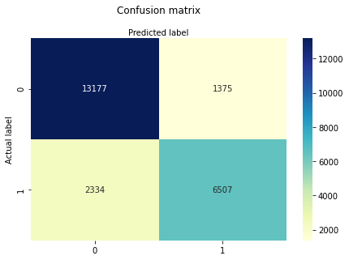

```
Accuracy: 0.8414482964989527
Precision: 0.8255518903831515
Recall: 0.7360027146250424
```

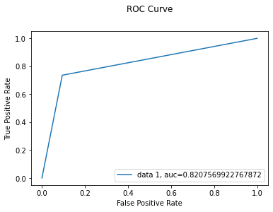

```python
evaluate_model(test_y,y_pred)
```

[figure not shown]

```python
# Create a pd.Series of features importances
importances_dt = pd.Series(dt.feature_importances_,
index = X.columns)
# Sort importances_rf
sorted_importances_dt = importances_dt.sort_values()
# Make a horizontal bar plot
sorted_importances_dt.plot(kind='barh', color='blue',figsize=(20,16))
plt.show()
```

- For Decision Tree Models we can also understand the feature imporatnces of all our features. It looks like the most importart feature by large is the deposit_type which agrees our intuition that if a guest put down deposit he or she is less likely to cancel the hotel room.

We could also see the nodes and leafs of the Decision Tree to understand the detailed classificaiton steps it took.

```python
r = export_text(dt, feature_names=list(X.columns))
print(r)
```

```
|--- deposit_type <= 0.50
|   |--- same_room_type <= 0.50
|   |   |--- country <= 134.50
|   |   |   |--- market_segment <= 5.50
|   |   |   |   |--- lead_time <= 98.50
|   |   |   |   |   |--- market_segment <= 4.50
|   |   |   |   |   |   |--- class: 0
|   |   |   |   |   |--- market_segment >  4.50
|   |   |   |   |   |   |--- class: 0
|   |   |   |   |--- lead_time >  98.50
|   |   |   |   |   |--- class: 0
|   |   |   |--- market_segment >  5.50
|   |   |   |   |--- lead_time <= 17.50
|   |   |   |   |   |--- class: 0
|   |   |   |   |--- lead_time >  17.50
|   |   |   |   |   |--- class: 0
|   |   |--- country >  134.50
|   |   |   |--- lead_time <= 74.50
|   |   |   |   |--- total_of_special_requests <= 0.50
|   |   |   |   |   |--- lead_time <= 2.50
|   |   |   |   |   |   |--- class: 0
|   |   |   |   |   |--- lead_time >  2.50
|   |   |   |   |   |   |--- class: 0
|   |   |   |   |--- total_of_special_requests >  0.50
|   |   |   |   |   |--- class: 0
|   |   |   |--- lead_time >  74.50
|   |   |   |   |--- class: 0
|   |--- same_room_type >  0.50
|   |   |--- required_car_parking_spaces <= 0.50
|   |   |   |--- lead_time <= 8.50
|   |   |   |   |--- country <= 134.50
|   |   |   |   |   |--- market_segment <= 5.50
|   |   |   |   |   |   |--- country <= 51.50
|   |   |   |   |   |   |   |--- class: 0
|   |   |   |   |   |   |--- country >  51.50
|   |   |   |   |   |   |   |--- class: 0
|   |   |   |   |   |--- market_segment >  5.50
|   |   |   |   |   |   |--- total_of_special_requests <= 0.50
|   |   |   |   |   |   |   |--- class: 0
|   |   |   |   |   |   |--- total_of_special_requests >  0.50
```

[output cut: 99 more lines]

```
|   |   |   |   |   |   |   |   |--- class: 0
|   |   |   |   |   |   |   |--- market_segment >  5.50
|   |   |   |   |   |   |   |   |--- class: 0
|   |   |   |   |   |--- previous_cancellations >  0.50
|   |   |   |   |   |   |--- class: 1
|   |   |--- required_car_parking_spaces >  0.50
|   |   |   |--- class: 0
|--- deposit_type >  0.50
|   |--- customer_type <= 2.50
|   |   |--- lead_time <= 53.50
|   |   |   |--- class: 1
|   |   |--- lead_time >  53.50
|   |   |   |--- class: 1
|   |--- customer_type >  2.50
|   |   |--- class: 1
```

#### Random Forest

Repeat the same process for Random Forest

```python
rf=RandomForestClassifier()

param_map = {
    "max_depth":[7,8,9,10,11,12,13,14],
    "min_samples_leaf":[0.01,0.01,0.05,0.1]
}
gs = GridSearchCV(rf, param_map,cv = 5, n_jobs = 4)
gs.fit(train_X,train_y)
gs.best_params_
```

```
{'max_depth': 13, 'min_samples_leaf': 0.01}
```

To make sure that our model doesn't have overfitting or underfitting issues, we then computed the accuracy score of the trainng data set as well as the cross validation scores. We got a training set accuracy score of 82% and cross validaition score of 82%. Since our testing, training and cross validation scores are the same, it's a good indicator that we don't have overfitting or underfitting problems in our model.

```python
# Initiate a random forests regressor 'rf' 400 estimators
rf = RandomForestClassifier(n_estimators=400,
                            max_depth= 13,
                            min_samples_leaf=0.01,
                            random_state=42)

# Fit 'rf' to the training set
rf.fit(train_X, train_y)

# Predict the test set labels 'y_pred'
y_pred = rf.predict(test_X)
y_pred_train=rf.predict(train_X)

# Evaluate the test set RMSE
acc_test = accuracy_score(test_y, y_pred)
acc_train = accuracy_score(train_y, y_pred_train)

# Print the test set RMSE
print('Test set accuracy of rf: {:.2f}'.format(acc_test))
print('Train set accuracy of rf: {:.2f}'.format(acc_train))
```

```
Test set accuracy of rf: 0.82
Train set accuracy of rf: 0.82
```

```python
cv_results = cross_validate(rf, train_X, train_y, cv=5)
cv_results['test_score']
```

```
array([0.82008122, 0.81906594, 0.8169285 , 0.82029497, 0.81724912])
```

```python
f"Cross Valiation accuracy: {round(sum(cv_results['test_score'])/5,2)}"
```

```
'Cross Valiation accuracy: 0.82'
```

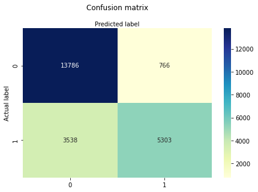

```
Accuracy: 0.8160133373231309
Precision: 0.8737848080408634
Recall: 0.5998190249971722
```

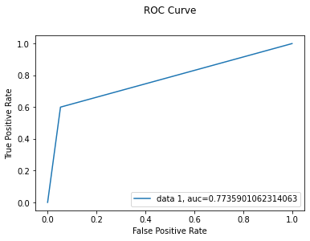

```python
evaluate_model(test_y,y_pred)
```

To take a closer look at the model performance, we print out the Confusion Matrix and the Accuracy, Precision and Recall scores. Precision which is stating that the of the cancelations the model predicted, 87% of them actually cancelled. Recall which is stating that model is 60% sensitive to predict cancellations from guests who actually cancelled. While the Precision score of the Random Forest is higher than the Decision Tree, the Recall score is lower.

For RandomForest Models we can also understand the feature imporatnces of all our features. It looks like the most importart feature by large is the deposit_type which agrees our intuition that if a guest put down deposit he or she is less likely to cancel the hotel room.

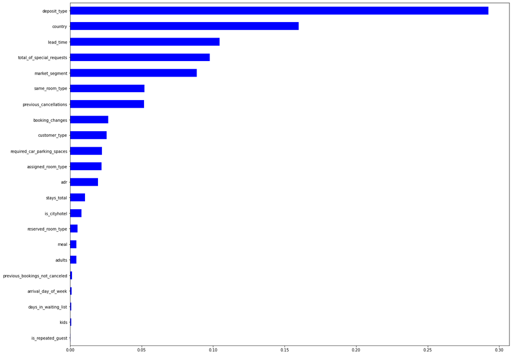

```python
# Create a pd.Series of features importances
importances_rf = pd.Series(rf.feature_importances_,
index = X.columns)
# Sort importances_rf
sorted_importances_rf = importances_rf.sort_values()
# Make a horizontal bar plot
sorted_importances_rf.plot(kind='barh', color='blue',figsize=(20,16))
plt.show()
```

### Logistic Regression

```python
logReg=LogisticRegression()

logReg.fit(train_X, train_y)

y_pred = logReg.predict(test_X)
```

```python
# Predict test set labels
y_pred = logReg.predict(test_X)

# Compute test set accuracy
acc = accuracy_score(test_y, y_pred)
print("Test set accuracy of Log: {:.2f}".format(acc))
```

```
Test set accuracy of Log: 0.77
```

```python
# Predict the labels of the training set
y_pred_train = logReg.predict(train_X)

# Evaluate the training set RMSE of dt
acc_train = accuracy_score(train_y, y_pred_train)

# Print RMSE_train
print('Train set accuracy of Log: {:.2f}'.format(acc_train))
```

```
Train set accuracy of Log: 0.77
```

```python
cv_results = cross_validate(logReg, train_X, train_y, cv=5)
cv_results['test_score']
```

```
array([0.76766057, 0.77209576, 0.76653842, 0.76579032, 0.76456129])
```

```python
f"Cross Valiation accuracy: {round(sum(cv_results['test_score'])/5,2)}"
```

```
'Cross Valiation accuracy: 0.77'
```

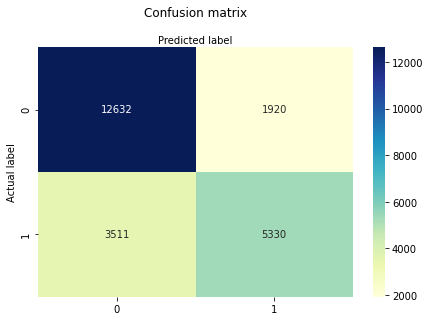

```
Accuracy: 0.767836532295986
Precision: 0.7351724137931035
Recall: 0.6028729781698903
```

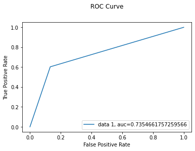

```python
evaluate_model(test_y,y_pred)
```

```python
Log_importance = logReg.coef_[0]
Log_importance
```

```
array([ 0.00541418, -0.21786565, -0.03966538,  0.01128227,  0.19049377,
       -0.11553669,  0.42671276, -0.47561908,  0.58352157, -0.67709321,
       -0.6544796 ,  0.80050232, -0.00221448, -1.0171665 ,  0.00450996,
       -0.40997088, -0.92626351, -0.03792979,  0.1187621 ,  0.16973645,
        0.11589668,  0.00635006])
```

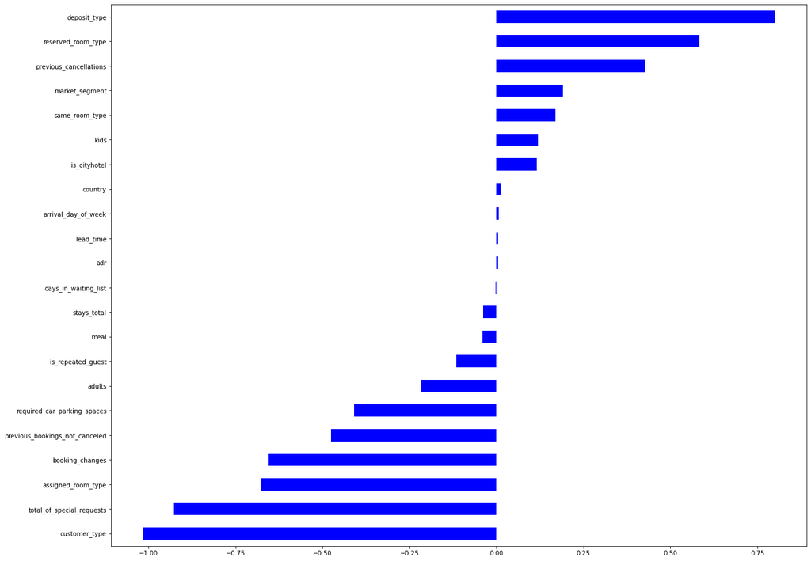

```python
# Create a pd.Series of features importances
importances_log = pd.Series(Log_importance,
index = X.columns)
# Sort importances
sorted_importances_log = importances_log.sort_values()
# Make a horizontal bar plot
sorted_importances_log.plot(kind='barh', color='blue',figsize=(20,16))
plt.show()
```

There are some questionable choices for feature selection, most of the most influential were of low occurance. If we are fitting on data with very few of the important features, which would be more typical in a real world sense, the model would be a poor fit more often than not.

### CatBoost

CatBoost is model that is based on gradient boosted decision trees. A set of decision trees is built consecutively during training where each successive tree is built with reduced loss compared to the previous trees.

```python
model_cb = CatBoostClassifier()
model_cb.fit(train_X, train_y)
```

[output not shown]

[output cut: 946 more lines]

[output not shown]

```
<catboost.core.CatBoostClassifier at 0x7fe7fb5b27d0>
```

```python
# Predict test set labels
y_pred = model_cb.predict(test_X)

# Compute test set accuracy
acc = accuracy_score(test_y, y_pred)
print("Test set accuracy of CatBoost: {:.2f}".format(acc))
```

```
Test set accuracy of CatBoost: 0.87
```

```python
# Predict the labels of the training set
y_pred_train = model_cb.predict(train_X)

# Evaluate the training set RMSE of dt
acc_train = accuracy_score(train_y, y_pred_train)

# Print RMSE_train
print('Train set accuracy of CatBoost: {:.2f}'.format(acc_train))
```

```
Train set accuracy of CatBoost: 0.88
```

```python
cv_results = cross_validate(model_cb, train_X, train_y, cv=5)
cv_results['test_score']
```

```python
f"Cross Valiation accuracy: {round(sum(cv_results['test_score'])/5,2)}"
```

```
'Cross Valiation accuracy: 0.87'
```

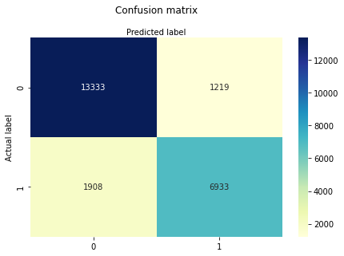

```
Accuracy: 0.8663275338776557
Precision: 0.8504661432777233
Recall: 0.7841873091279267
```

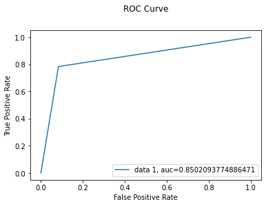

```python
evaluate_model(test_y, y_pred)
```

Much better recall score than the previous models

### Shap Value Plot

The SHAP value plot can further show the positive and negative relationships of the predictors with the target variable. What SHAP does is quantifying the contribution that each feature brings to the prediction made by the model. SHAP values interpret the impact of having a certain value for a given feature in comparison to the prediction we'd make if that feature took some baseline value.

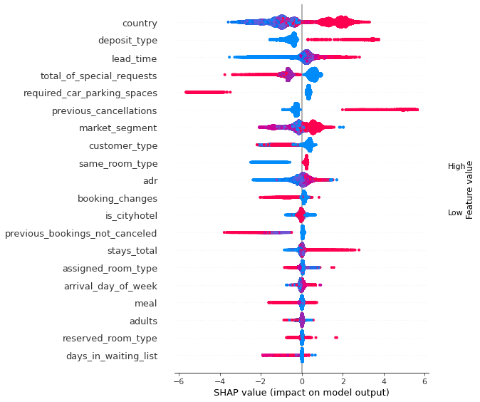

```python
shap_values = shap.TreeExplainer(model_cb).shap_values(train_X)
shap.summary_plot(shap_values, train_X)
```

The country of a Reservation has a high probability of being cancelled. Depending on the country, the chances of a reservation being cancelled is the highest among other features. However, this result has to be interpreted with caution because in real life, we don't always have the nationality of the person until they check in to the hotel.

### XG Boost

```python
# Gamma, the larger the more conervative
gamma = [0.1,3,5]

# Maximum number of levels in tree
max_depth = [int(x) for x in np.linspace(1, 5, num = 5)]

# Minimum sum of instance weight (hessian) needed in a child.
min_child_weight = [int(x) for x in np.linspace(1, 5, num = 5)]

# Subsample ratio of the training instances.
subsample = [float(x) for x in np.linspace(0.1, 1, num = 10)]

# Subsample ratio of columns when constructing each tree
colsample_bytree = [float(x) for x in np.linspace(0.1, 1, num = 10)]

# Create the XGB grid
xgb_grid = {'gamma': gamma,
            'max_depth': max_depth,
            'min_child_weight': min_child_weight,
            'subsample': subsample,
            'colsample_bytree': colsample_bytree}

# Use the XGB grid to search for best hyperparameters
# First create the base model to tune
xgb = XGBClassifier()

# Random search of parameters, using 5 fold cross validation,
# search across 100 different combinations, and use all available cores
xgb_random = RandomizedSearchCV(estimator = xgb, param_distributions = xgb_grid, n_iter = 100, cv = 5, verbose=0,scoring='accuracy',
                                 random_state=42, n_jobs = -1)

# Fit the random search model
xgb_random.fit(train_X, train_y)
```

```
RandomizedSearchCV(cv=5, estimator=XGBClassifier(), n_iter=100, n_jobs=-1,
                   param_distributions={'colsample_bytree': [0.1, 0.2,
                                                             0.30000000000000004,
                                                             0.4, 0.5, 0.6,
                                                             0.7000000000000001,
                                                             0.8, 0.9, 1.0],
                                        'gamma': [0.1, 3, 5],
                                        'max_depth': [1, 2, 3, 4, 5],
                                        'min_child_weight': [1, 2, 3, 4, 5],
                                        'subsample': [0.1, 0.2,
                                                      0.30000000000000004, 0.4,
                                                      0.5, 0.6,
                                                      0.7000000000000001, 0.8,
                                                      0.9, 1.0]},
                   random_state=42, scoring='accuracy')
```

```python
xgb_random.best_params_
```

```
{'subsample': 0.2,
 'min_child_weight': 2,
 'max_depth': 5,
 'gamma': 3,
 'colsample_bytree': 1.0}
```

```python
#Fit XGB Classifer
xgb = XGBClassifier(gamma=3, max_depth=8, min_child_weight=1, subsample=0.9, colsample_bytree=1.0, random_state=42)
#xgb = XGBClassifier()
xgb.fit(train_X,train_y)
```

```
XGBClassifier(colsample_bytree=1.0, gamma=3, max_depth=8, random_state=42,
              subsample=0.9)
```

```python
# Predict test set labels
y_pred_xgb = xgb.predict(test_X)

# Compute test set accuracy
acc = accuracy_score(test_y, y_pred_xgb)
print("Test set accuracy of XGB: {:.5f}".format(acc))
```

```
Test set accuracy of XGB: 0.85945
```

```python
# Predict the labels of the training set
y_pred_train_xgb = xgb.predict(train_X)

# Evaluate the training set RMSE of dt
acc_train = accuracy_score(train_y, y_pred_train_xgb)

# Print RMSE_train
print('Train set accuracy of XGB: {:.5f}'.format(acc_train))
```

```
Train set accuracy of XGB: 0.86777
```

```python
Accuracy_CV_scores = cross_val_score(xgb, train_X, train_y, cv=5,
                                     scoring='accuracy',
                                     n_jobs=-1)

print(Accuracy_CV_scores)
print("XGB Accuracy score (CV): {0:.3f}".format(Accuracy_CV_scores.mean()))
```

```
[0.86448648 0.85668483 0.86160094 0.86053222 0.85898258]
XGB Accuracy score (CV): 0.860
```

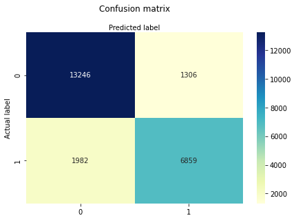

```
Accuracy: 0.8594451331594921
Precision: 0.8400489895897122
Recall: 0.775817215247144
```

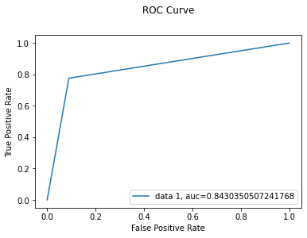

```python
evaluate_model(test_y, y_pred_xgb)
```

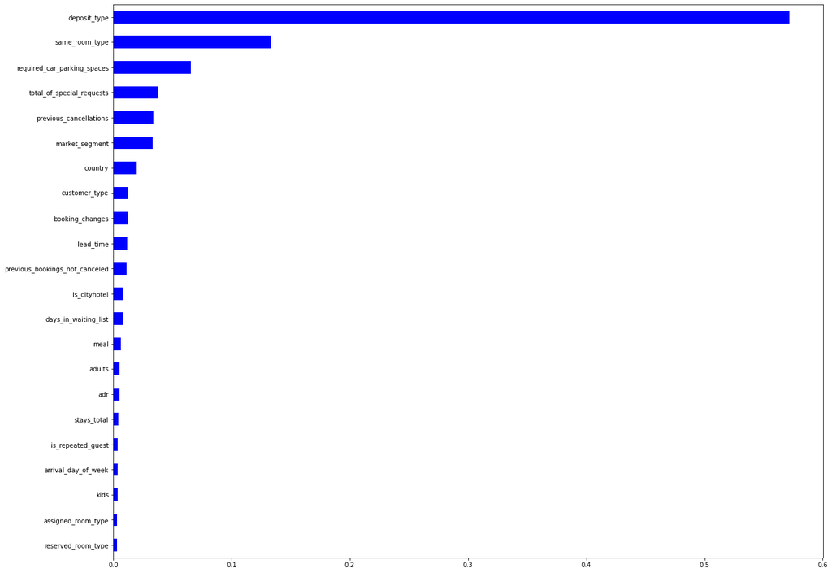

```python
# Create a pd.Series of features importances
importances_xgb = pd.Series(xgb.feature_importances_,
index = X.columns)
# Sort importances_xgb
sorted_importances_xgb = importances_xgb.sort_values()
# Make a horizontal bar plot
sorted_importances_xgb.plot(kind='barh', color='blue',figsize=(20,16))
plt.show()
```

```python
# another way of finding feature importance
xgb_feature_importances = pd.DataFrame(list(zip(train_X.columns.values,xgb.feature_importances_)),
                                       columns =['Feafure', 'Importance'])
xgb_feature_importances=xgb_feature_importances.sort_values(by=['Importance'], ascending=False)
```

```python
xgb_feature_importances
```

|  | Feafure | Importance |
| --- | --- | --- |
| 11 | deposit_type | 0.571679 |
| 19 | same_room_type | 0.133506 |
| 15 | required_car_parking_spaces | 0.065644 |
| 16 | total_of_special_requests | 0.037591 |
| 6 | previous_cancellations | 0.033733 |
| 4 | market_segment | 0.033388 |
| 3 | country | 0.020139 |
| 13 | customer_type | 0.012422 |
| 10 | booking_changes | 0.012360 |
| 0 | lead_time | 0.012072 |
| 7 | previous_bookings_not_canceled | 0.011237 |
| 20 | is_cityhotel | 0.008591 |
| 12 | days_in_waiting_list | 0.008140 |
| 2 | meal | 0.006258 |
| 1 | adults | 0.005298 |
| 14 | adr | 0.005229 |
| 17 | stays_total | 0.004568 |
| 5 | is_repeated_guest | 0.003955 |
| 21 | arrival_day_of_week | 0.003723 |
| 18 | kids | 0.003707 |
| 9 | assigned_room_type | 0.003447 |
| 8 | reserved_room_type | 0.003312 |

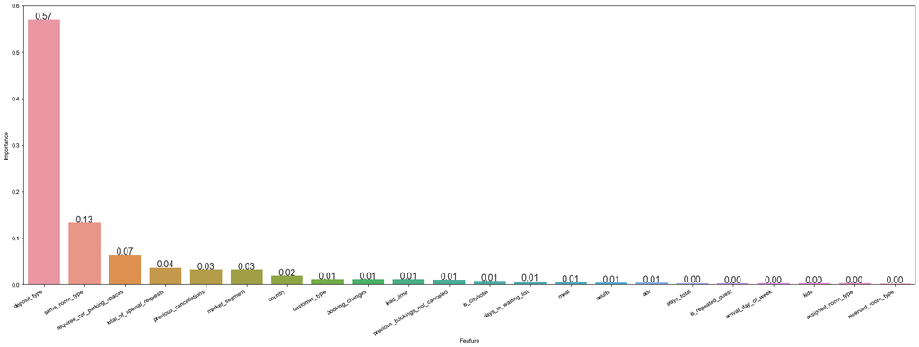

```python
# method 2 of plotting feature importance. This only acts as an alternative to put on the presentation slides
fig, ax = plt.subplots()
fig.set_size_inches(28, 10)
sns.set(font_scale = 1.3)
ax = sns.barplot(x="Feafure", y="Importance", data=xgb_feature_importances)
fig.autofmt_xdate()

def show_values_on_bars(axs):
    def _show_on_single_plot(ax):
        for p in ax.patches:
            _x = p.get_x() + p.get_width() / 2
            _y = p.get_y() + p.get_height()
            value = '{:.2f}'.format(p.get_height())
            ax.text(_x, _y, value, ha="center")

    if isinstance(axs, np.ndarray):
        for idx, ax in np.ndenumerate(axs):
            _show_on_single_plot(ax)
    else:
        _show_on_single_plot(axs)

show_values_on_bars(ax)
```

#### Voting Classifier

```python
# Define the list classifiers
classifiers = [('Logistics Regression', logReg),
               ('CatBoost', model_cb),
               ('Decision Tree', dt),
               ('Random Forest',rf),
               ('XGBoost', xgb)]
```

```python
for clf_name, clf in classifiers:

    # Fit clf to the training set
    clf.fit(train_X, train_y)

    # Predict y_pred
    y_pred = clf.predict(test_X)

    # Calculate accuracy
    accuracy = accuracy_score(test_y, y_pred)

    # Evaluate clf's accuracy on the test set
    print('{:s} : {:.3f}'.format(clf_name, accuracy))
```

[output not shown]

[output cut: 951 more lines]

[output not shown]

```python
# Instantiate a VotingClassifier vc
vc = VotingClassifier(estimators=classifiers, voting='hard')

# Fit vc to the training set
vc.fit(train_X, train_y)

# Evaluate the test set predictions
y_pred = vc.predict(test_X)

# Calculate accuracy score
accuracy = accuracy_score(test_y, y_pred)
```

```python
print('Hard Voting Classifier: {:.3f}'.format(accuracy))
```

```
Hard Voting Classifier: 0.856
```

```python
# Instantiate a VotingClassifier vc
vc = VotingClassifier(estimators=classifiers, voting='soft')

# Fit vc to the training set
vc.fit(train_X, train_y)

# Evaluate the test set predictions
y_pred = vc.predict(test_X)

# Calculate accuracy score
accuracy = accuracy_score(test_y, y_pred)
```

```python
print('Soft Voting Classifier: {:.3f}'.format(accuracy))
```

```
Soft Voting Classifier: 0.857
```

```python
# Predict the labels of the training set
y_pred_train = vc.predict(train_X)

# Evaluate the training set RMSE of dt
acc_train = accuracy_score(train_y, y_pred_train)

# Print RMSE_train
print('Train set accuracy of dt: {:.2f}'.format(acc_train))
```

```
Train set accuracy of dt: 0.86
```

```python
cv_results = cross_validate(vc, train_X, train_y, cv=5)
cv_results['test_score']
```

```python
f"Cross Valiation accuracy: {round(sum(cv_results['test_score'])/5,2)}"
```

[output not shown]

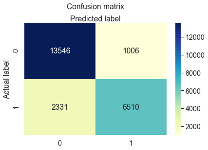

```
Accuracy: 0.8573504894626598
Precision: 0.8661522086216072
Recall: 0.7363420427553444
```

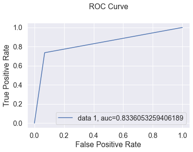

```python
evaluate_model(test_y, y_pred)
```

```python
classification_report(test_y,y_pred)
```

[output not shown]